# homework5

Yamei Li, Meirou Guan, Tamires Amorim, Carol-Ann Jackson

10/29/2020

we improve some of our regression models to explain wages, we want to look at wages for Asian women with at least a college degree。

```r
setwd("/Users/yameili/Desktop/ecob2000_lecture1/acs2017_ny")
load("acs2017_ny_data.Rdata")
attach(acs2017_ny)
use_varb <- (AGE >= 25) & (AGE <= 55) & (LABFORCE == 2) & (WKSWORK2 > 4) & (UHRSWORK >= 35) & (Asian == 1)
dat_use <- subset(acs2017_ny,use_varb) #
detach()
attach(dat_use)
```

At the beginning, I do the nonlinear regression between the wage and age and age-squared.

```r
lm1<-lm(INCWAGE~AGE+I(AGE^2),data=dat_use)
par(mfrow=c(2,2))
plot(lm1,col="grey",pch=16,cex=1,lwd=1,lty=2)
summary(lm1)
```

```
##
## Call:
## lm(formula = INCWAGE ~ AGE + I(AGE^2), data = dat_use)
##
## Residuals:
##    Min     1Q Median     3Q    Max
## -87225 -46992 -18413  15680 581622
##
## Coefficients:
##               Estimate Std. Error t value Pr(>|t|)
## (Intercept) -135204.43   29073.37  -4.650 3.40e-06 ***
## AGE           10737.23    1501.24   7.152 9.87e-13 ***
## I(AGE^2)       -129.56      18.69  -6.934 4.65e-12 ***
## ---
## Signif. codes:  0 '***' 0.001 '**' 0.01 '*' 0.05 '.' 0.1 ' ' 1
##
## Residual standard error: 89290 on 4645 degrees of freedom
## Multiple R-squared:  0.0116, Adjusted R-squared:  0.01117
## F-statistic: 27.25 on 2 and 4645 DF,  p-value: 1.718e-12
```

```r
require(stargazer)
stargazer(lm1, type = "text")
```

```
##
## ===============================================
##                         Dependent variable:
##                     ---------------------------
##                               INCWAGE
## -----------------------------------------------
## AGE                        10,737.230***
##                             (1,501.236)
##
## I(AGE2)                     -129.564***
##                              (18.685)
##
## Constant                  -135,204.400***
##                            (29,073.370)
##
## -----------------------------------------------
## Observations                   4,648
## R2                             0.012
## Adjusted R2                    0.011
## Residual Std. Error   89,292.740 (df = 4645)
## F Statistic          27.248*** (df = 2; 4645)
## ===============================================
## Note:               *p<0.1; **p<0.05; ***p<0.01
```

```r
require(AER)
```

[figure not shown]

```r
NNobs <- length(INCWAGE)
set.seed(12345)
graph_obs <- (runif(NNobs) < 0.1)
dat_graph <-subset(dat_use,graph_obs)
a<-plot(INCWAGE ~ jitter(AGE, factor = 2), pch = 16, col = rgb(0.5, 0.7, 0.8, alpha = 0.8), ylim = c(0,150000), data = dat_graph)
summary(a)
```

```
## Length  Class   Mode
##      0   NULL   NULL
```

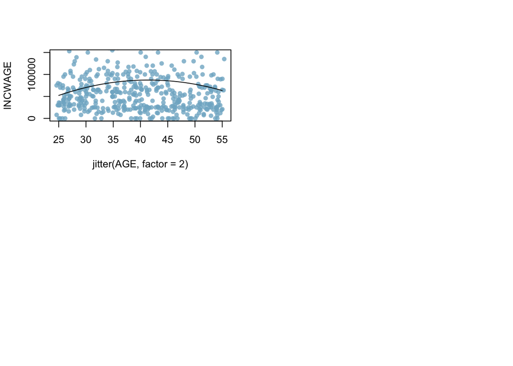

```r
to_be_predicted1 <- data.frame(AGE = 25:55, female = 1, AfAm = 0, Asian = 1, Amindian = 0, race_oth = 0, Hispanic =0, educ_hs = 0, educ_somecoll = 0, educ_college = 1, educ_advdeg = 0)
to_be_predicted1$yhat <- predict(lm1, newdata = to_be_predicted1)
lines(yhat ~ AGE, data = to_be_predicted1)
```

```r
lm2<-lm(INCWAGE~AGE+I(AGE^2)+I(AGE^3)+I(AGE^4),data=dat_use)
summary(lm2)
```

```
##
## Call:
## lm(formula = INCWAGE ~ AGE + I(AGE^2) + I(AGE^3) + I(AGE^4),
##     data = dat_use)
##
## Residuals:
##    Min     1Q Median     3Q    Max
## -92184 -47239 -18434  16149 584159
##
## Coefficients:
##               Estimate Std. Error t value Pr(>|t|)
## (Intercept)  1.736e+06  7.036e+05   2.468 0.013617 *
## AGE         -2.026e+05  7.454e+04  -2.718 0.006600 **
## I(AGE^2)     8.745e+03  2.901e+03   3.015 0.002588 **
## I(AGE^3)    -1.597e+02  4.920e+01  -3.247 0.001176 **
## I(AGE^4)     1.050e+00  3.071e-01   3.419 0.000633 ***
## ---
## Signif. codes:  0 '***' 0.001 '**' 0.01 '*' 0.05 '.' 0.1 ' ' 1
##
## Residual standard error: 89080 on 4643 degrees of freedom
## Multiple R-squared:  0.01662,    Adjusted R-squared:  0.01577
## F-statistic: 19.62 on 4 and 4643 DF,  p-value: 5.004e-16
```

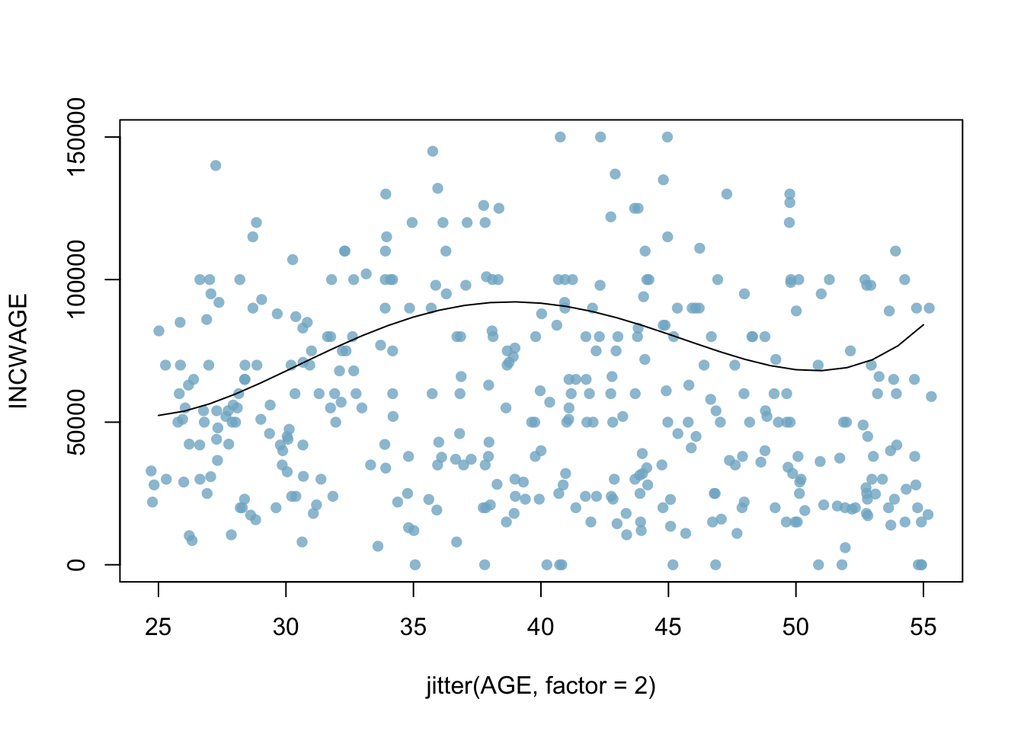

```r
NNobs <- length(INCWAGE)
set.seed(22222)
graph_obs <- (runif(NNobs) < 0.1)
dat_graph <-subset(dat_use,graph_obs)
b<-plot(INCWAGE ~ jitter(AGE, factor = 2), pch = 16, col = rgb(0.5, 0.7, 0.8, alpha = 0.8), ylim = c(0,150000), data = dat_graph)
to_be_predicted2 <- data.frame(AGE = 25:55, female = 1, AfAm = 0, Asian = 1, Amindian = 0, race_oth = 0, Hispanic =0, educ_hs = 0, educ_somecoll = 0, educ_college = 1, educ_advdeg = 0)
to_be_predicted2$yhat <- predict(lm2, newdata = to_be_predicted2)
lines(yhat ~ AGE, data = to_be_predicted2)
```

```r
lm3<-lm(INCWAGE~log(AGE)+I(log(AGE^2)),data=dat_use)
summary(lm3)
```

```
##
## Call:
## lm(formula = INCWAGE ~ log(AGE) + I(log(AGE^2)), data = dat_use)
##
## Residuals:
##    Min     1Q Median     3Q    Max
## -83611 -47964 -19684  16757 568573
##
## Coefficients: (1 not defined because of singularities)
##               Estimate Std. Error t value Pr(>|t|)
## (Intercept)       7748      21272   0.364  0.71572
## log(AGE)         18931       5804   3.262  0.00112 **
## I(log(AGE^2))       NA         NA      NA       NA
## ---
## Signif. codes:  0 '***' 0.001 '**' 0.01 '*' 0.05 '.' 0.1 ' ' 1
##
## Residual standard error: 89700 on 4646 degrees of freedom
## Multiple R-squared:  0.002285,   Adjusted R-squared:  0.00207
## F-statistic: 10.64 on 1 and 4646 DF,  p-value: 0.001116
```

when we use log(AGE^2) to do regression, I get NA, for p-value, they are not significantly, it will change the significant level. The reason is that i get a perfect multicolinearity when I put log(AGE^2) with log(AGE), so it is useless.

```r
lm4<-lm(INCWAGE~AGE+I(AGE^2)+educ_college+educ_advdeg,data=dat_use)
summary(lm4)
```

```
##
## Call:
## lm(formula = INCWAGE ~ AGE + I(AGE^2) + educ_college + educ_advdeg,
##     data = dat_use)
##
## Residuals:
##     Min      1Q  Median      3Q     Max
## -129470  -36139  -14973   14689  600679
##
## Coefficients:
##                Estimate Std. Error t value Pr(>|t|)
## (Intercept)  -182449.22   27344.05  -6.672 2.81e-11 ***
## AGE            10524.85    1404.92   7.491 8.11e-14 ***
## I(AGE^2)        -118.71      17.48  -6.792 1.24e-11 ***
## educ_college   49402.16    2937.22  16.819  < 2e-16 ***
## educ_advdeg    78647.44    3102.27  25.352  < 2e-16 ***
## ---
## Signif. codes:  0 '***' 0.001 '**' 0.01 '*' 0.05 '.' 0.1 ' ' 1
##
## Residual standard error: 83410 on 4643 degrees of freedom
## Multiple R-squared:  0.1379, Adjusted R-squared:  0.1372
## F-statistic: 185.7 on 4 and 4643 DF,  p-value: < 2.2e-16
```

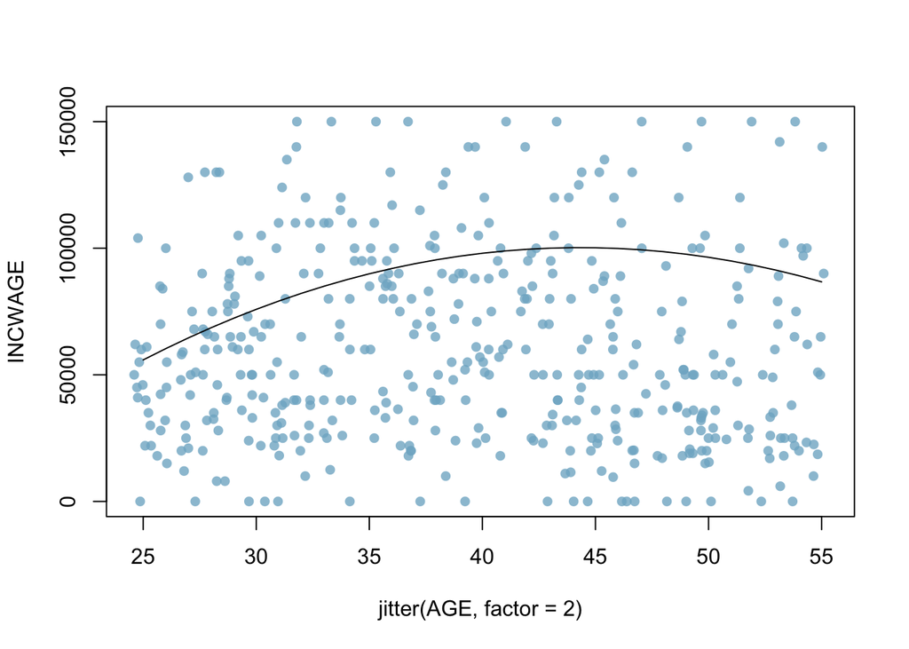

```r
NNobs <- length(INCWAGE)
set.seed(33333)
graph_obs <- (runif(NNobs) < 0.1)
dat_graph <-subset(dat_use,graph_obs)
b<-plot(INCWAGE ~ jitter(AGE, factor = 2), pch = 16, col = rgb(0.5, 0.7, 0.8, alpha = 0.8), ylim = c(0,150000), data = dat_graph)
to_be_predicted3 <- data.frame(AGE = 25:55, female = 1, AfAm = 0, Asian = 1, Amindian = 0, race_oth = 0, Hispanic =0, educ_hs = 0, educ_somecoll = 0, educ_college = 1, educ_advdeg = 0)
to_be_predicted3$yhat <- predict(lm4, newdata = to_be_predicted3)
lines(yhat ~ AGE, data = to_be_predicted3)
```

The interpretation of coefficient on educ_college in my subset is that keep the other variables constant, when a female get a college degree, her income will increase 49402.16. I choose for dummy variables in my regression,educ_hs;educ_somecoll;duc_college and educ_advdeg, the reason why i couldn’t add educ_nohs variable is because if i add it, there have a Dummy Variable Trap.

```r
lm5<-lm(INCWAGE~AGE+I(AGE^2)+educ_hs+educ_somecoll+educ_college+educ_advdeg,data=dat_use)
summary(lm5)
```

```
##
## Call:
## lm(formula = INCWAGE ~ AGE + I(AGE^2) + educ_hs + educ_somecoll +
##     educ_college + educ_advdeg, data = dat_use)
##
## Residuals:
##     Min      1Q  Median      3Q     Max
## -129809  -36019  -13687   13694  604564
##
## Coefficients:
##                 Estimate Std. Error t value Pr(>|t|)
## (Intercept)   -195148.84   27584.85  -7.074 1.72e-12 ***
## AGE             10549.48    1402.57   7.522 6.46e-14 ***
## I(AGE^2)         -118.15      17.45  -6.771 1.44e-11 ***
## educ_hs          7404.96    5155.45   1.436    0.151
## educ_somecoll   22234.31    5548.04   4.008 6.23e-05 ***
## educ_college    60345.25    4891.29  12.337  < 2e-16 ***
## educ_advdeg     89483.11    4977.41  17.978  < 2e-16 ***
## ---
## Signif. codes:  0 '***' 0.001 '**' 0.01 '*' 0.05 '.' 0.1 ' ' 1
##
## Residual standard error: 83260 on 4641 degrees of freedom
## Multiple R-squared:  0.1414, Adjusted R-squared:  0.1403
## F-statistic: 127.4 on 6 and 4641 DF,  p-value: < 2.2e-16
```

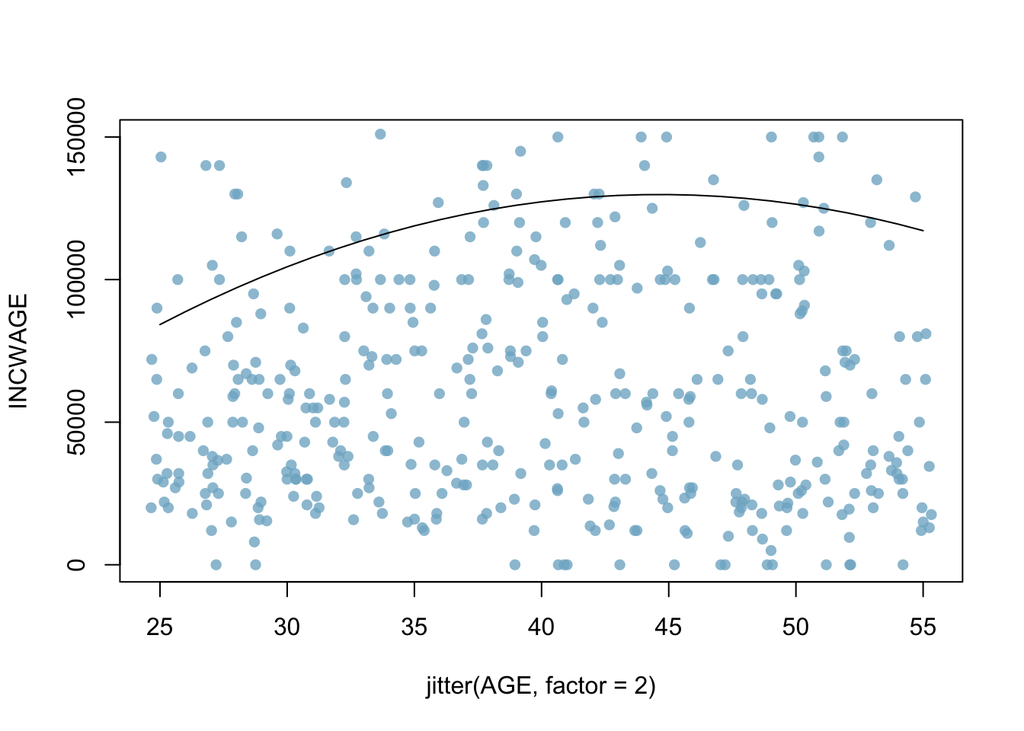

```r
NNobs <- length(INCWAGE)
set.seed(44444)
graph_obs <- (runif(NNobs) < 0.1)
dat_graph <-subset(dat_use,graph_obs)
b<-plot(INCWAGE ~ jitter(AGE, factor = 2), pch = 16, col = rgb(0.5, 0.7, 0.8, alpha = 0.8), ylim = c(0,150000), data = dat_graph)
to_be_predicted4 <- data.frame(AGE = 25:55, female = 1, AfAm = 0, Asian = 1, Amindian = 0, race_oth = 0, Hispanic =0, educ_hs = 0, educ_somecoll = 0, educ_college = 0, educ_advdeg = 1)
to_be_predicted4$yhat <- predict(lm5, newdata = to_be_predicted4)
lines(yhat ~AGE , data = to_be_predicted4)
```

we can see from the result, high school degree is not significantly with the income wage, because the p value is 0.151 greater than 0.01, except the high school degree, other variables are all significantly on the confidence level. we also can know that there are positive relationship between the degree with income, especially People with higher education level tend to have higher incomes, and a master’s or bachelor’s degree can make people earn more money.if you get college degree, your income will increase 60345.25, and if you get advance degree, your income will increase 89483.11.

```r
lm6<-lm(log1p(INCWAGE)~AGE+I(AGE^2)+educ_hs+educ_somecoll+educ_college+educ_advdeg,data=dat_use)
summary(lm6)
```

```
##
## Call:
## lm(formula = log1p(INCWAGE) ~ AGE + I(AGE^2) + educ_hs + educ_somecoll +
##     educ_college + educ_advdeg, data = dat_use)
##
## Residuals:
##      Min       1Q   Median       3Q      Max
## -11.2518  -0.0423   0.3827   0.8243   3.8697
##
## Coefficients:
##                 Estimate Std. Error t value Pr(>|t|)
## (Intercept)    7.5675681  0.7356087  10.287  < 2e-16 ***
## AGE            0.1145077  0.0374025   3.061  0.00221 **
## I(AGE^2)      -0.0014222  0.0004653  -3.056  0.00225 **
## educ_hs       -0.0668975  0.1374810  -0.487  0.62657
## educ_somecoll  0.3786743  0.1479502   2.559  0.01051 *
## educ_college   0.9807934  0.1304368   7.519 6.57e-14 ***
## educ_advdeg    1.3801613  0.1327331  10.398  < 2e-16 ***
## ---
## Signif. codes:  0 '***' 0.001 '**' 0.01 '*' 0.05 '.' 0.1 ' ' 1
##
## Residual standard error: 2.22 on 4641 degrees of freedom
## Multiple R-squared:  0.06138,    Adjusted R-squared:  0.06016
## F-statistic: 50.58 on 6 and 4641 DF,  p-value: < 2.2e-16
```

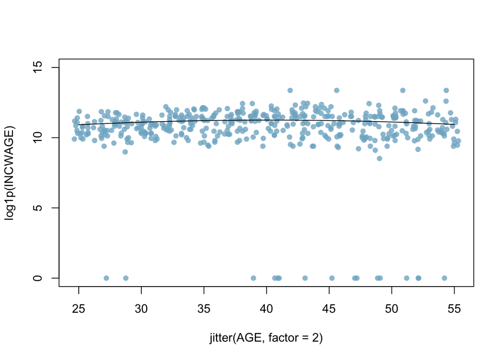

```r
NNobs <- length(log1p(INCWAGE))
set.seed(44444)
graph_obs <- (runif(NNobs) < 0.1)
dat_graph <-subset(dat_use,graph_obs)
plot(log1p(INCWAGE) ~ jitter(AGE, factor = 2), pch = 16, col = rgb(0.5, 0.7, 0.8, alpha = 0.8), ylim = c(0,15), data = dat_graph)
to_be_predicted5 <- data.frame(AGE = 25:55, female = 1, AfAm = 0, Asian = 1, Amindian = 0, race_oth = 0, Hispanic =0, educ_hs = 0, educ_somecoll = 0, educ_college = 0, educ_advdeg = 1)
to_be_predicted5$yhat <- predict(lm6, newdata = to_be_predicted5)
lines(yhat ~AGE , data = to_be_predicted5)
```

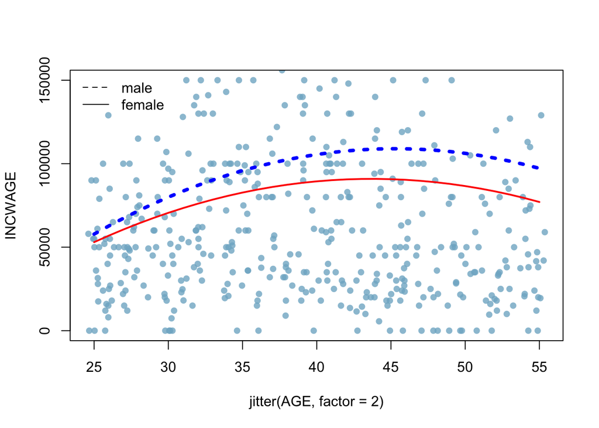

```r
lm7<-lm(INCWAGE ~ AGE + I(AGE^2) + female + I(female*AGE) + I(female*(AGE^2))+educ_somecoll+educ_college+educ_advdeg,data=dat_use)
NNobs <- length(INCWAGE)
set.seed(66666)
graph_obs <- (runif(NNobs) < 0.1)
dat_graph <-subset(dat_use,graph_obs)
plot(INCWAGE ~ jitter(AGE, factor = 2), pch = 16, col = rgb(0.5, 0.7, 0.8, alpha = 0.8), ylim = c(0,150000), data = dat_graph)
to_be_predicted6 <- data.frame(AGE = 25:55, female = 1, AfAm = 0, Asian =1, Amindian = 0, race_oth = 0, Hispanic =0, educ_hs = 0, educ_somecoll = 0, educ_college = 1, educ_advdeg = 0)
to_be_predicted6$yhat <- predict(lm7, newdata = to_be_predicted6)
lines(yhat ~ AGE, data = to_be_predicted6,col="red",lwd=2)
to_be_predicted7 <- data.frame(AGE = 25:55, female = 0, AfAm = 0, Asian =1, Amindian = 0, race_oth = 0, Hispanic =0, educ_hs = 0, educ_somecoll = 0, educ_college = 1, educ_advdeg = 0)
to_be_predicted7$yhat <- predict(lm7, newdata = to_be_predicted7)
lines(yhat ~ AGE, data = to_be_predicted7,col="blue",lty=3,lwd=4)
legend("topleft", c("male", "female"), lty = c(2,1), bty = "n")
```

we can see that there is a gap between female and male, men’s wage are higher than women’s wage.